# Set_13

Alexander Williams

2024-11-19

# Non-linear Regression

all previous examples either were linear, or had methods to represent the data in a linear system. This cannot be done for these non-linear models.

### Example: Growth of deer jaw

theory indicates that the length of a deer’s jaw bone changes as they age.

```r
deer<-read.table(file ='~/Documents/uni/STAT359/data/jaws.txt',header=TRUE,sep="")
attach(deer)
names(deer)
```

```
## [1] "age"  "bone"
```

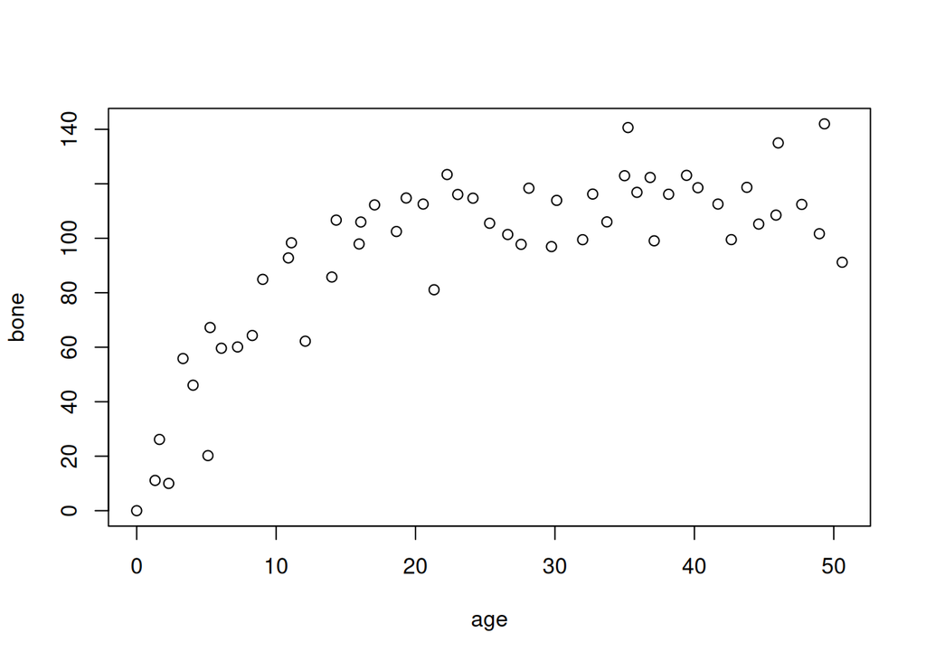

```r
plot(age, bone)
```

the data appears to grow quickly at first, but slows down as they age.

We want to examine the data, and end up with a confidence interval for the curve.

We want to use the following non-linear model:
$$y_i=a-be^{-cx_i}+\epsilon_i$$
where : $a$ is the asymptote epsilon is $\epsilon\sim{}N(0,\sigma^2)$

in R, we use `nls()`to minimize RSS for non-linear squares.it’s an iterative process. We need to be careful to choose good starting values for this, and we can’t guarantee that our predictions will converge to a good result.

How do we get good initial values?

$a$ is our asymptote, we can estimate that to be around 120.

note that $f(0)=a-b$, and in this case it looks like $f(0)=0$, so $b\approx120$ is a good starting value

$c$ is a bit harder to estimate. We can ignore $\epsilon$ in our equation, and make the assumption that $f(\bar{X})=\bar{Y}$
$$c=\log(\frac{120}{120-\bar{Y}})/\bar{X}$$

```r
a <- 120
b <- 120
c<-log(120/(120-mean(bone)))/mean(age)
c
```

```
## [1] 0.06162808
```

```r
library(nls2)
model<-nls(bone~a-b*exp(-c*age), # Equation we want to model the data with
           start = list(a=a,b=b,c=c)) # Starting values for a,b,c
summary(model)
```

```
##
## Formula: bone ~ a - b * exp(-c * age)
##
## Parameters:
##   Estimate Std. Error t value Pr(>|t|)
## a 115.2528     2.9139   39.55  < 2e-16 ***
## b 118.6875     7.8925   15.04  < 2e-16 ***
## c   0.1235     0.0171    7.22 2.44e-09 ***
## ---
## Signif. codes:  0 '***' 0.001 '**' 0.01 '*' 0.05 '.' 0.1 ' ' 1
##
## Residual standard error: 13.21 on 51 degrees of freedom
##
## Number of iterations to convergence: 5
## Achieved convergence tolerance: 3.693e-06
```

what if we use bad starting values?

```r
#model<-nls(bone~a-b*exp(-c*age),start = list(a=1,b=1,c=1))
#summary(model)
```

This causes an error, as it doesn’t converge

How to get our confidence interval?
$$\bar{\theta}\pm{}Z_{\alpha/2}SE(\hat{\theta})$$
where $\hat{\theta}$ are the estimated model parameters **Note**: We are assuming that the parameters are normally distributed, which may not always be the case.

```r
model<-nls(bone~a-b*exp(-c*age),start = list(a=120,b=120,c=0.061))
## confidence intervals for a, b,c
a.CI<-c(115.2528-1.96*2.9139,115.2528+1.96*2.9139)
b.CI<-c(118.6875-1.96*7.8925,118.6875+1.96*7.8925)
c.CI<-c(0.1235 - 1.96*0.0171,0.1235 + 1.96*0.0171)
rbind(a.CI,b.CI,c.CI)
```

```
##            [,1]       [,2]
## a.CI 109.541556 120.964044
## b.CI 103.218200 134.156800
## c.CI   0.089984   0.157016
```

Looking at this data, the confidence intervals for $a$ and $b$ overlap. This might suggest that we could use a simpler model where $a=b$. What does that look like?

```r
model2 <- nls(bone~a-a*exp(-c*age),
              start=c(a=a,c=c))

anova(model2, model)
```

```
## Analysis of Variance Table
##
## Model 1: bone ~ a - a * exp(-c * age)
## Model 2: bone ~ a - b * exp(-c * age)
##   Res.Df Res.Sum Sq Df Sum Sq F value Pr(>F)
## 1     52     8929.1
## 2     51     8897.3  1 31.843  0.1825  0.671
```

with such a high p-value, we have no reason to believe that our original model is any better than the new, simpler model

or, computed manually:

```r
1-pf(0.1825,1,51)
```

```
## [1] 0.6710318
```

Now, lets plot our new model

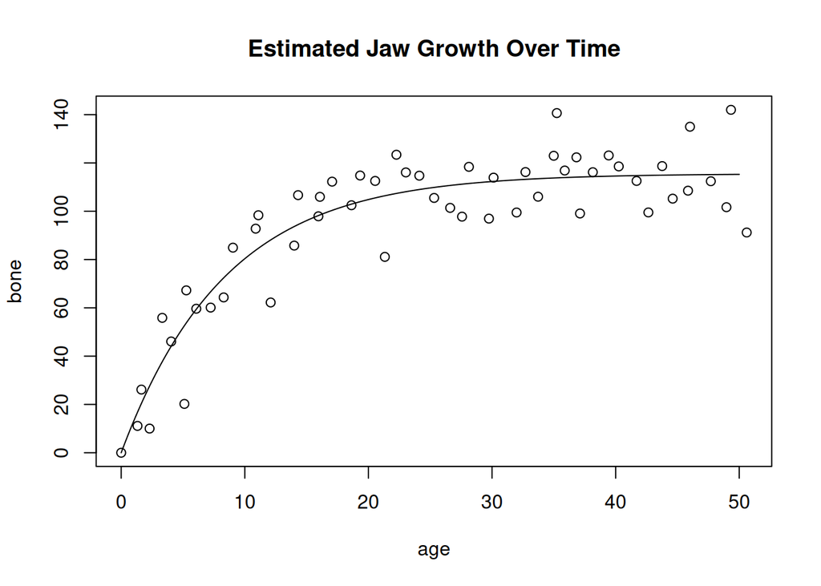

```r
plot(age, bone)
age.fit<-seq(0,50,.1)
b.length.fit<-predict(model2,list(age=age.fit))
lines(age.fit,b.length.fit)
title("Estimated Jaw Growth Over Time")
```

Now, lets get a confidence interval for this curve, like a band around it.
$$\hat{f}(t)\pm{}Z_{\alpha/2}SE(\hat{\hat{f}(t)})$$

$$SE(\hat{f}(t))=\sqrt{\hat{VAR}(\hat{f}(t))}$$
and for this model,
$$\hat{f}(t)=\hat{a}-\hat{a}e^{\hat{c}t}$$
What we can get out of R with our fitted model is a matrix of the estimated covariance of a and c $C_{\hat{a},\hat{c}}$

```r
C.hat<-vcov(model2)
C.hat
```

```
##             a             c
## a  8.08633164 -0.0238274539
## c -0.02382745  0.0001520623
```

```r
sqrt(diag(C.hat)) # diag(matrix) returns a diagonalized matrix
```

```
##          a          c
## 2.84364759 0.01233135
```

Now we have an estimate of the covariance of $\hat{a},\hat{c}$. now we want an estimate of $VAR(\hat{f}(t))$. It’s found as a first order Taylor expansion.
$$\hat{VAR}(\hat{f}(t))=(1-e^{-\hat{c}t)}*t\hat{a}e^{-\hat{c}t})C_{\hat{a},\hat{c}}vector((1-e^{-\hat{c}t}),(t\hat{a}e^{-\hat{c}t}))$$

```r
summary(model2)
```

```
##
## Formula: bone ~ a - a * exp(-c * age)
##
## Parameters:
##    Estimate Std. Error t value Pr(>|t|)
## a 115.58056    2.84365  40.645  < 2e-16 ***
## c   0.11882    0.01233   9.635 3.69e-13 ***
## ---
## Signif. codes:  0 '***' 0.001 '**' 0.01 '*' 0.05 '.' 0.1 ' ' 1
##
## Residual standard error: 13.1 on 52 degrees of freedom
##
## Number of iterations to convergence: 5
## Achieved convergence tolerance: 1.678e-06
```

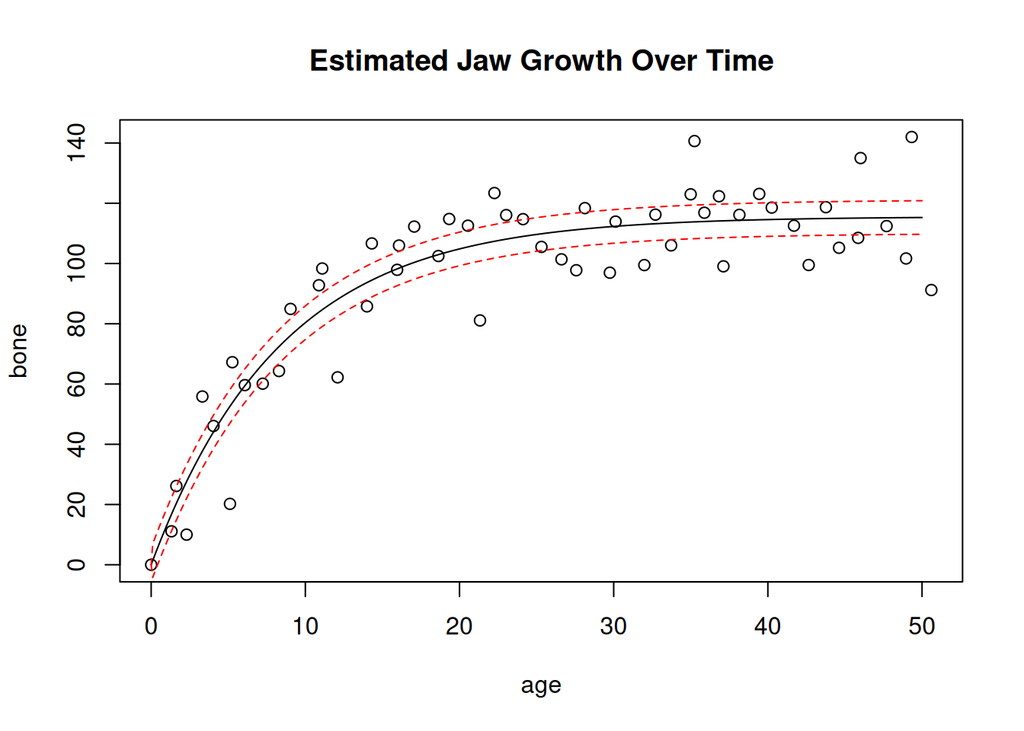

```r
# plot points
plot(age, bone)

# plot the line of best fit
age.fit<-seq(0,50,.1)
b.length.fit<-predict(model2,list(age=age.fit))
lines(age.fit,b.length.fit)
title("Estimated Jaw Growth Over Time")


# Get a-hat and c-hat from the model
a.hat <- coef(model2)[1]
c.hat <- coef(model2)[1]

## compute VAR(f(t))
# obtain the estimated covariance matrix of (a.hat,c.hat)
C.hat<-vcov(model2)

# vector will hold the variance of f.hat across time points
# it's a vector because variance changes with respect to t, it's not a consistent value
v.f.hat<-rep(0,length(age.fit))
t<-age.fit # all the t points
for (i in 1:length(t))
{
  # evaluate the gradient of f(t) at estimates
  grad.f<-c(1-exp(-c.hat*t[i]), t[i]*a.hat*exp(-c.hat*t[i]))
  # compute the variance
  v.f.hat[i]<-t(grad.f)%*%C.hat%*%grad.f # %*% is matrix multiplication

} # this could have been vectorized

#standard error
SE.f<-sqrt(v.f.hat)
# 95% confidence interval
f.lower<-b.length.fit - 1.96*SE.f
f.upper<-b.length.fit + 1.96*SE.f
lines(age.fit,f.lower,col='red',lty=2)
lines(age.fit,f.upper,col='red',lty=2)
```